# Statistics with R. Testing with continuous variables

UEB

# hta dataset

```r
hta <- read_excel("datasets/hta.xls")
hta[1:5,1:9]
```

| numero | sexo | grupo | tas1 | tad1 | tas2 | tad2 | tas3 | tad3 |
| --- | --- | --- | --- | --- | --- | --- | --- | --- |
| 1 | VARON | B | 150 | 100 | 150 | 90 | 170 | 90 |
| 2 | MUJER | B | 160 | 90 | 170 | 90 | 160 | 80 |
| 3 | MUJER | B | 150 | 90 | 110 | 90 | 115 | 90 |
| 4 | VARON | A | 120 | 80 | 140 | 90 | 140 | 90 |
| 5 | MUJER | A | 150 | 85 | 145 | 85 | 160 | 90 |

# Checking Normality

## Graphically

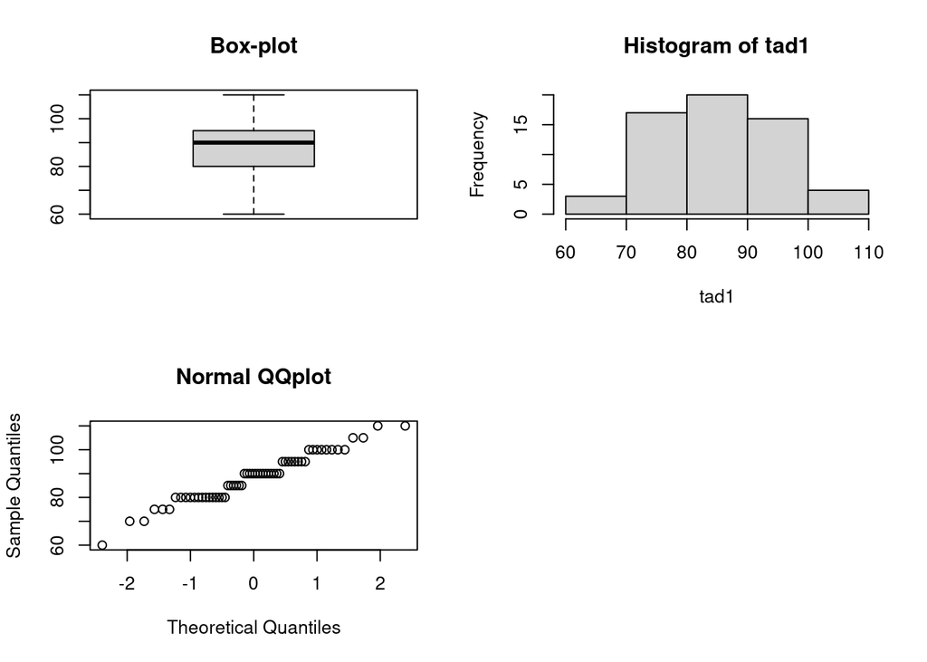

```r
oldpar<-par(mfrow=c(1,1)) # Guarda los parámetros para el dibgujo
par(mfrow=c(2,2)) # Dibuja cuatro gráficos por grafico
with(hta, boxplot(tad1, main="Box-plot") )

with(hta, hist(tad1) )

with(hta, qqnorm(tad1, main="Normal QQplot") );with(hta, qqline(tas1) )

par(oldpar) # Vuelve a los parámetros de dibujo originales
```

## Normality Test

```r
with(hta,shapiro.test(tad1) ) # Shapiro Wilk test
```

```
##
##  Shapiro-Wilk normality test
##
## data:  tad1
## W = 0.96622, p-value = 0.09512
```

# One sample Test

```r
with(hta,t.test(tad1,mu=90) ) # One sample T.test
```

```
##
##  One Sample t-test
##
## data:  tad1
## t = -1.2137, df = 59, p-value = 0.2297
## alternative hypothesis: true mean is not equal to 90
## 95 percent confidence interval:
##  85.80626 91.02707
## sample estimates:
## mean of x
##  88.41667
```

# Two groups comparison in independent samples

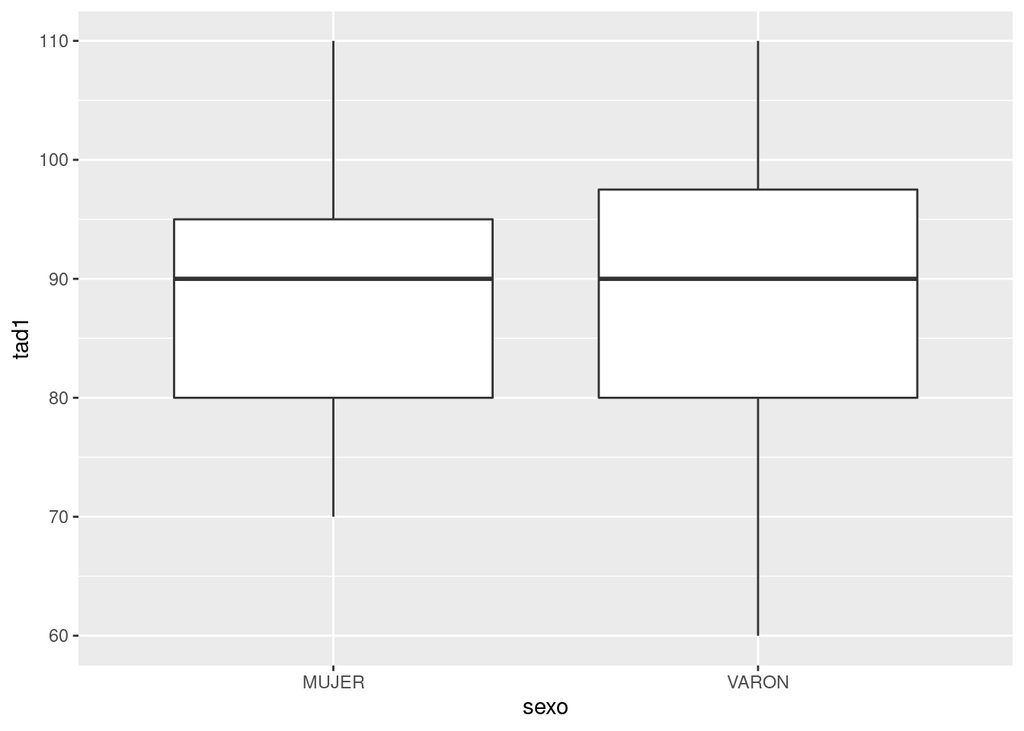

```r
ggplot(hta, aes(x=sexo, y=tad1)) +
  geom_boxplot()
```

## Homogeneity variance Test

```r
library(car)
hta%>%
  group_by(sexo) %>%
  summarise(var = sd(tad1))
```

| sexo | var |
| --- | --- |
| MUJER | 9.083364 |
| VARON | 11.757598 |

```r
with(hta,leveneTest(tad1~factor(sexo),center="median"))
```

|  | Df | F value | Pr(>F) |
| --- | --- | --- | --- |
| group | 1 | 1.350616 | 0.2499304 |
|  | 58 | NA | NA |

- p value is over 0.05
- We can assume homogeneity of variances

## T test when variances are equal

```r
with(hta,t.test(tad1~factor(sexo),var.equal=TRUE ))
```

```
##
##  Two Sample t-test
##
## data:  tad1 by factor(sexo)
## t = 0.35427, df = 58, p-value = 0.7244
## alternative hypothesis: true difference in means between group MUJER and group VARON is not equal to 0
## 95 percent confidence interval:
##  -4.453505  6.368899
## sample estimates:
## mean in group MUJER mean in group VARON
##            88.78378            87.82609
```

- Type I Error is over than 0.05
- We cannot reject mean equality

## T test when variances are unequal

```r
with(hta,t.test(tas1~factor(sexo),var.equal=FALSE ))
```

```
##
##  Welch Two Sample t-test
##
## data:  tas1 by factor(sexo)
## t = -0.23436, df = 39.098, p-value = 0.8159
## alternative hypothesis: true difference in means between group MUJER and group VARON is not equal to 0
## 95 percent confidence interval:
##  -12.277927   9.727986
## sample estimates:
## mean in group MUJER mean in group VARON
##            149.5946            150.8696
```

- Same conclusions as before
- Test is also known as Welch test

## U Mann-Whitney or Sum Rank non parametric test

```r
with(hta,wilcox.test(tad1~factor(sexo)
    ,alternative='two.sided',exact=TRUE, correct=FALSE))
```

```
##
##  Wilcoxon rank sum test
##
## data:  tad1 by factor(sexo)
## W = 434, p-value = 0.8955
## alternative hypothesis: true location shift is not equal to 0
```

```r
hta%>%
  group_by(sexo) %>%
  summarise(median = median(tad1))
```

| sexo | median |
| --- | --- |
| MUJER | 90 |
| VARON | 90 |

- Null Hypothesis cannot be rejected

# Two groups comparison in dependent samples

## Paired T-test

```r
with(hta,t.test(tad1,tad12,paired=TRUE))
```

```
##
##  Paired t-test
##
## data:  tad1 and tad12
## t = 1.8507, df = 51, p-value = 0.07001
## alternative hypothesis: true difference in means is not equal to 0
## 95 percent confidence interval:
##  -0.2364274  5.8133505
## sample estimates:
## mean of the differences
##                2.788462
```

```r
summary(hta$tad1)
```

```
##    Min. 1st Qu.  Median    Mean 3rd Qu.    Max.
##   60.00   80.00   90.00   88.42   95.00  110.00
```

```r
summary(hta$tad12)
```

```
##    Min. 1st Qu.  Median    Mean 3rd Qu.    Max.    NA's
##   60.00   80.00   85.00   84.62   90.00  100.00       8
```

- P value is over 0.05

## Paired Sign-Rank Wilcoxon Test

```r
with(hta,wilcox.test(tad1,tad12,
     exact=TRUE, paired=TRUE))
```

```
##
##  Wilcoxon signed rank test with continuity correction
##
## data:  tad1 and tad12
## V = 478.5, p-value = 0.05333
## alternative hypothesis: true location shift is not equal to 0
```

# diabetes dataset

```r
diabetes <- read_excel("datasets/diabetes.xls")
diabetes[1:5,1:9]
```

| numpacie | mort | tempsviu | edat | bmi | edatdiag | tabac | sbp | dbp |
| --- | --- | --- | --- | --- | --- | --- | --- | --- |
| 1 | Vivo | 12.4 | 44 | 34.2 | 41 | No fumador | 132 | 96 |
| 2 | Vivo | 12.4 | 49 | 32.6 | 48 | Fumador | 130 | 72 |
| 3 | Vivo | 9.6 | 49 | 22.0 | 35 | Fumador | 108 | 58 |
| 4 | Vivo | 7.2 | 47 | 37.9 | 45 | No fumador | 128 | 76 |
| 5 | Vivo | 14.1 | 43 | 42.2 | 42 | Fumador | 142 | 80 |

```r
sapply(diabetes, class)
```

```
##    numpacie        mort    tempsviu        edat         bmi    edatdiag
##   "numeric" "character"   "numeric"   "numeric"   "numeric"   "numeric"
##       tabac         sbp         dbp         ecg         chd
## "character"   "numeric"   "numeric" "character" "character"
```

```r
diabetes_factor <- diabetes %>%
  mutate_if(sapply(diabetes, is.character), as.factor) %>%
  select (-numpacie)
```

# More than two groups comparison in independent samples

```r
diabetes%>%
  group_by(ecg) %>%
  summarise( n=n(),
    mean = mean(edat),
            sd=sd(edat))
```

| ecg | n | mean | sd |
| --- | --- | --- | --- |
| Anormal | 11 | 64.90909 | 6.759505 |
| Frontera | 27 | 53.81481 | 11.368097 |
| Normal | 111 | 50.50450 | 11.492981 |

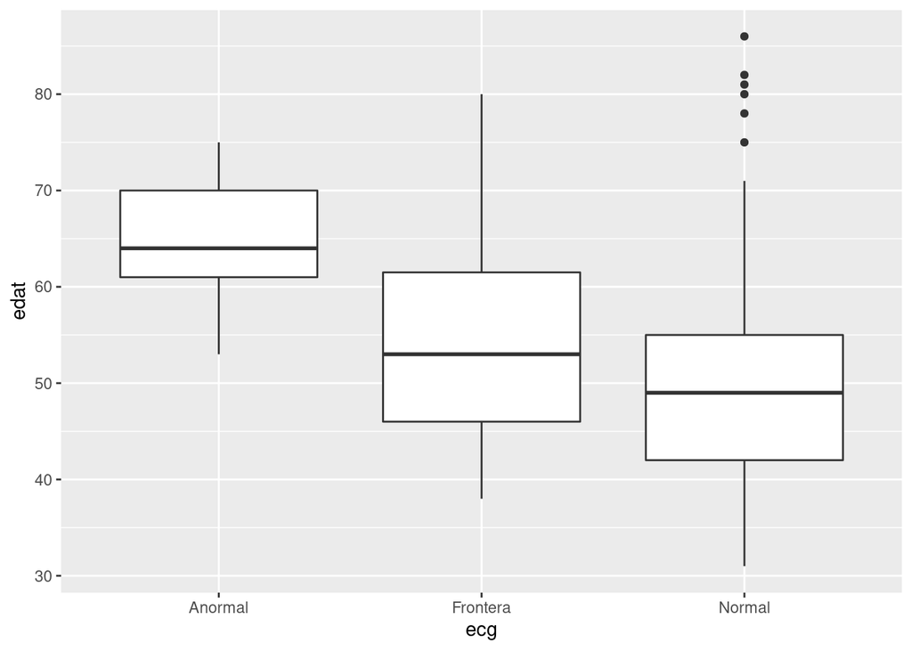

```r
ggplot(diabetes, aes(x=ecg, y=edat)) +
  geom_boxplot()
```

## ANOVA

```r
anova<-aov(edat~ecg,data=diabetes_factor)
summary(anova)
```

```
##              Df Sum Sq Mean Sq F value  Pr(>F)
## ecg           2   2166  1083.0   8.619 0.00029 ***
## Residuals   146  18347   125.7
## ---
## Signif. codes:  0 '***' 0.001 '**' 0.01 '*' 0.05 '.' 0.1 ' ' 1
```

### Tukey test for multiple comparison

```r
# install.packages("multcomp")
library(multcomp)
tuk <- glht(anova, linfct = mcp(ecg = "Tukey"))

  print(summary(tuk)) # pairwise tests
```

```
##
##   Simultaneous Tests for General Linear Hypotheses
##
## Multiple Comparisons of Means: Tukey Contrasts
##
##
## Fit: aov(formula = edat ~ ecg, data = diabetes_factor)
##
## Linear Hypotheses:
##                         Estimate Std. Error t value Pr(>|t|)
## Frontera - Anormal == 0  -11.094      4.010  -2.767 0.016457 *
## Normal - Anormal == 0    -14.405      3.543  -4.065 0.000217 ***
## Normal - Frontera == 0    -3.310      2.405  -1.376 0.345710
## ---
## Signif. codes:  0 '***' 0.001 '**' 0.01 '*' 0.05 '.' 0.1 ' ' 1
## (Adjusted p values reported -- single-step method)
```

**Confidence intervals:**

```r
print(confint(tuk, level=0.95)) # confidence intervals
```

```
##
##   Simultaneous Confidence Intervals
##
## Multiple Comparisons of Means: Tukey Contrasts
##
##
## Fit: aov(formula = edat ~ ecg, data = diabetes_factor)
##
## Quantile = 2.3458
## 95% family-wise confidence level
##
##
## Linear Hypotheses:
##                         Estimate lwr      upr
## Frontera - Anormal == 0 -11.0943 -20.5003  -1.6883
## Normal - Anormal == 0   -14.4046 -22.7168  -6.0924
## Normal - Frontera == 0   -3.3103  -8.9530   2.3324
```

**Multicomparison plot**

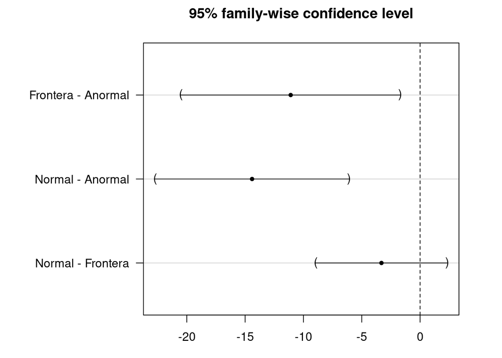

```r
par(mar=c(3,10,3,3))
plot(confint(tuk))
```

## Kruskal-Wallis Test (non-parametric)

```r
diabetes_factor%>%
  group_by(ecg) %>%
  summarise(median = median(edat))
```

| ecg | median |
| --- | --- |
| Anormal | 64 |
| Frontera | 53 |
| Normal | 49 |

```r
kruskal.test(edat~ecg,data=diabetes_factor)
```

```
##
##  Kruskal-Wallis rank sum test
##
## data:  edat by ecg
## Kruskal-Wallis chi-squared = 17.483, df = 2, p-value = 0.0001598
```

### Dunn Test for multiple comparison

```r
# install.packages("dunn.test")
library(dunn.test)
with(diabetes_factor,dunn.test(edat,ecg,method="bonferroni"))
```

```
##   Kruskal-Wallis rank sum test
##
## data: edat and ecg
## Kruskal-Wallis chi-squared = 17.4826, df = 2, p-value = 0
##
##
##                            Comparison of edat by ecg
##                                  (Bonferroni)
## Col Mean-|
## Row Mean |    Anormal   Frontera
## ---------+----------------------
## Frontera |   2.721182
##          |    0.0098*
##   Normal |   4.075469   1.467464
##          |    0.0001*     0.2134
##
## alpha = 0.05
## Reject Ho if p <= alpha/2
```

# Exercise solutions

## Exercise 1

1. Check the normality of tas1 variable in hta dataset

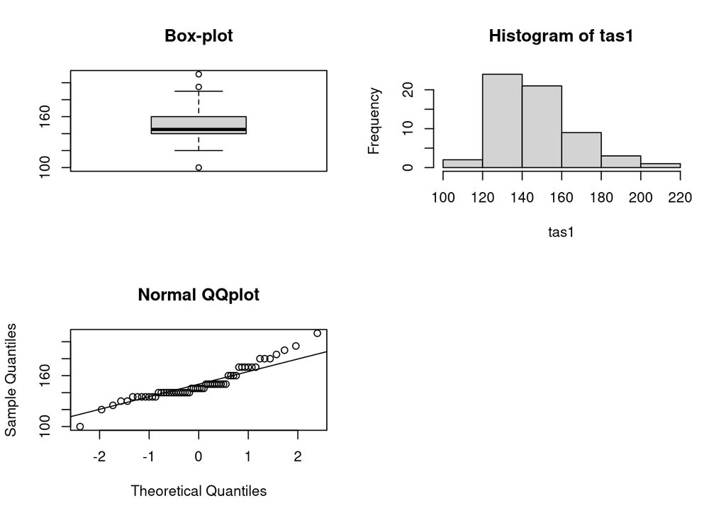

```r
oldpar<-par(mfrow=c(1,1)) # Guarda los parámetros para el dibgujo
par(mfrow=c(2,2)) # Dibuja cuatro gráficos por grafico
with(hta, boxplot(tas1, main="Box-plot") )

with(hta, hist(tas1) )

with(hta, qqnorm(tas1, main="Normal QQplot") );with(hta, qqline(tas1) )

par(oldpar) # Vuelve a los parámetros de dibujo originales
```

```r
with(hta,shapiro.test(tas1) ) # Shapiro Wilk test
```

```
##
##  Shapiro-Wilk normality test
##
## data:  tas1
## W = 0.91869, p-value = 0.0006796
```

2. Can it be accepted that the initial TAS is 120 in Hipertensive patients?

```r
with(hta,t.test(tas1,mu=120)) # One sample T.test
```

```
##
##  One Sample t-test
##
## data:  tas1
## t = 12.088, df = 59, p-value < 2.2e-16
## alternative hypothesis: true mean is not equal to 120
## 95 percent confidence interval:
##  145.1036 155.0631
## sample estimates:
## mean of x
##  150.0833
```

3. Find the 95% confidence interval for the mean of tas1 variable

From the test before we can find the confidence interval for the mean.

4. Extra: Can it be accepted that the initial TAS is higher than 120 in Hipertensive women?

```r
hta_w <- subset(hta, sexo=="MUJER")
with(hta_w,t.test(tas1,mu=120, alternative="greater")) # One sample T.test
```

```
##
##  One Sample t-test
##
## data:  tas1
## t = 10.22, df = 36, p-value = 1.73e-12
## alternative hypothesis: true mean is greater than 120
## 95 percent confidence interval:
##  144.7058      Inf
## sample estimates:
## mean of x
##  149.5946
```

## Exercise 2

Is TAD comparable at baseline time between groups?

We first plot the distribution of tad1 variables in each group

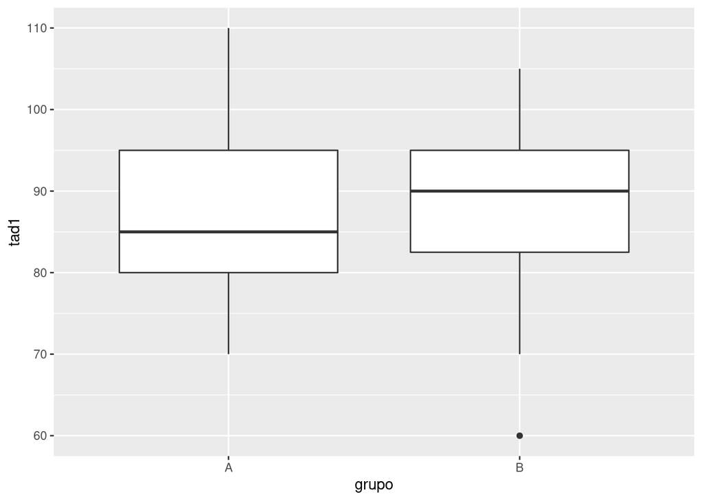

```r
ggplot(hta, aes(x=grupo, y=tad1)) +
  geom_boxplot()
```

Test for homogeneity of variances between the two groups

```r
hta%>%
  group_by(grupo) %>%
  summarise(var = sd(tad1))
```

| grupo | var |
| --- | --- |
| A | 10.597890 |
| B | 9.793568 |

```r
with(hta,leveneTest(tad1~factor(grupo), center="median"))
```

|  | Df | F value | Pr(>F) |
| --- | --- | --- | --- |
| group | 1 | 1.083924 | 0.3021418 |
|  | 58 | NA | NA |

- p value is over 0.05
- We can assume homogeneity of variances

We apply the t.test for equal variances

```r
with(hta,t.test(tad1~factor(grupo),var.equal=TRUE ))
```

```
##
##  Two Sample t-test
##
## data:  tad1 by factor(grupo)
## t = 0.15001, df = 58, p-value = 0.8813
## alternative hypothesis: true difference in means between group A and group B is not equal to 0
## 95 percent confidence interval:
##  -4.874549  5.664316
## sample estimates:
## mean in group A mean in group B
##        88.62069        88.22581
```

- Differences between groups are not significant.

Using a non-parametric test:

```r
with(hta,wilcox.test(tad1~factor(grupo), alternative='two.sided', exact=TRUE, correct=FALSE))
```

```
##
##  Wilcoxon rank sum test
##
## data:  tad1 by factor(grupo)
## W = 432, p-value = 0.7926
## alternative hypothesis: true location shift is not equal to 0
```

```r
hta%>%
  group_by(grupo) %>%
  summarise(median = median(tad1))
```

| grupo | median |
| --- | --- |
| A | 85 |
| B | 90 |

- We obtain similar results.

## Exercise 3

Is sistolic blood pressure (TAS) comparable between first and 12th measures?

```r
with(hta,t.test(tas1,tas12,paired=TRUE))
```

```
##
##  Paired t-test
##
## data:  tas1 and tas12
## t = 6.0672, df = 51, p-value = 1.609e-07
## alternative hypothesis: true difference in means is not equal to 0
## 95 percent confidence interval:
##   8.518285 16.943253
## sample estimates:
## mean of the differences
##                12.73077
```

```r
summary(hta$tas1)
```

```
##    Min. 1st Qu.  Median    Mean 3rd Qu.    Max.
##   100.0   140.0   145.0   150.1   160.0   210.0
```

```r
summary(hta$tas12)
```

```
##    Min. 1st Qu.  Median    Mean 3rd Qu.    Max.    NA's
##   110.0   130.0   139.0   137.2   150.0   175.0       8
```

- P value is below 0.05

With the non-parametric test Paired Sign-Rank Wilcoxon Test

```r
with(hta,wilcox.test(tas1,tas12,
     exact=TRUE, paired=TRUE))
```

```
##
##  Wilcoxon signed rank test with continuity correction
##
## data:  tas1 and tas12
## V = 1046, p-value = 2.398e-06
## alternative hypothesis: true location shift is not equal to 0
```

- We obtain similar results

## Exercise 4

1. Se efectúa un estudio de seguimiento a 1018 sujetos atendidos en una clínica de obesidad. Se mide el Indice de Masa Corporal(IMC) y el perfil lipídico. Al cabo de 12 meses se evalúa de nuevo el IMC y el colesterol estando interesados en cuantificar la disminución de ambos parámetros.

Disponemos de dos variables cuantitativas medidas en dos momentos distintos (muestras apareadas). Se quiere analizar si los valores pre y post sufren algun cambio, para ello debemos: en primer lugar evaluar la normalidad de las variables. En caso de que se ajusten a una distribución normal, miramos la homegeneidad de las variables y realizamos un test t de Student para muestras apareadas. En el caso de que no sigan una distribución normal, realizaremos el test no paramétrico de Wilcoxon para muestras apareadas.

2. Se analizan un grupo de variables inmunológicas (leucocitos totales, linfocitos B, natural Killer, etc) en una muestra de 102 hombres y 147 mujeres mayores de 65 años. Se está interesado en ver la existencia de diferencias por sexo.

Disponemos de distintas variables cuantitativas (leucocitos,linfocitos, etc. ) y una variable cualitativa, sexo. Queremos ver si existen diferencias de las variables cuantitativas según el sexo, para ello debemos: en primer lugar evaluar la normalidad de las variables. En caso de que se ajusten a una distribución normal, miramos la homegeneidad de las variables y realizamos un test t de Student. En el caso de que no sigan una distribución normal, realizaremos el test no paramétrico U de Mann-Whitnney.

## Exercise 5

Are there differences between systolic pressure (sbp) and ECG in diabetic patients?

Extra: And between the follow-up time (tempsviu) and the ECG?

1. For each variable, perform some descriptives and check normality assumptions
- Check normality

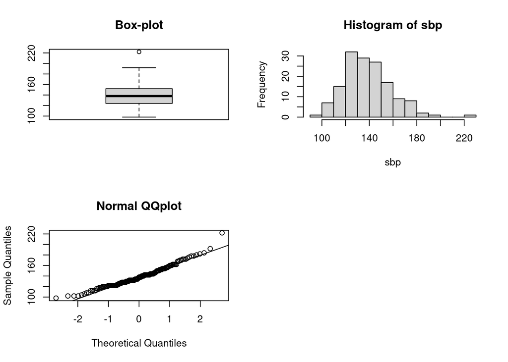

```r
oldpar<-par(mfrow=c(1,1)) # Guarda los parámetros para el dibgujo
par(mfrow=c(2,2)) # Dibuja cuatro gráficos por grafico
with(diabetes, boxplot(sbp, main="Box-plot") )

with(diabetes, hist(sbp) )

with(diabetes, qqnorm(sbp, main="Normal QQplot") );with(diabetes, qqline(sbp) )

par(oldpar) # Vuelve a los parámetros de dibujo originales
```

```r
with(diabetes,shapiro.test(sbp) ) # Shapiro Wilk test
```

```
##
##  Shapiro-Wilk normality test
##
## data:  sbp
## W = 0.96785, p-value = 0.001455
```

- Summarise variable by ECG group

```r
diabetes%>%
  group_by(ecg) %>%
  summarise( n=n(),
    mean = mean(sbp), median=median(sbp),
            sd=sd(sbp))
```

| ecg | n | mean | median | sd |
| --- | --- | --- | --- | --- |
| Anormal | 11 | 144.0000 | 150 | 21.14710 |
| Frontera | 27 | 143.5556 | 142 | 23.80261 |
| Normal | 111 | 137.5676 | 134 | 19.14425 |

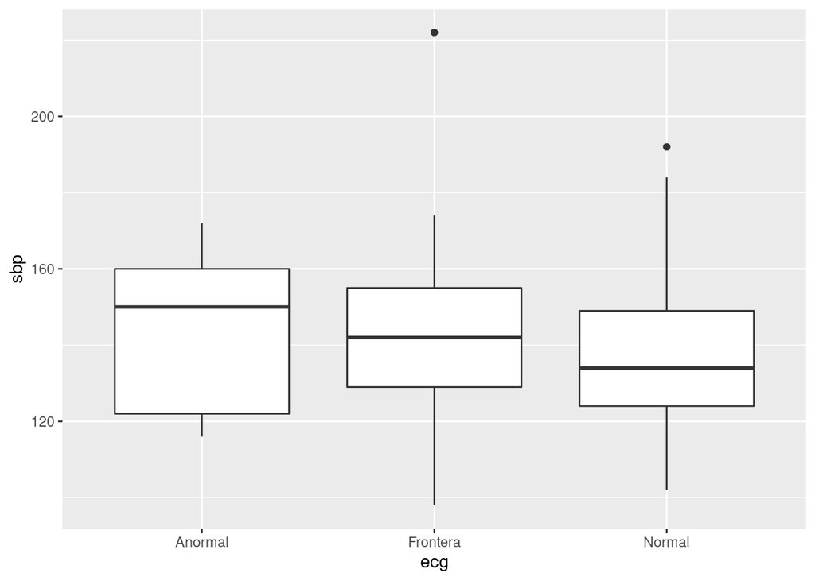

```r
ggplot(diabetes, aes(x=ecg, y=sbp)) +
  geom_boxplot()
```

2. Set the hypothesis contrast and perform the test

H0: The means of all the groups are equal H1: Not all the means are equal. At least there are two different means

```r
anova_sbp <-aov(sbp~ecg,data=diabetes_factor)
summary(anova_sbp)
```

```
##              Df Sum Sq Mean Sq F value Pr(>F)
## ecg           2   1061   530.3   1.301  0.275
## Residuals   146  59518   407.7
```

3. If needed, apply a post-hoc test for multiple comparisons between groups to test which groups are different.

Not needed here since we cannot reject the null hypothesis.

4. Extra: Analyze the relation between the follow-up time (tempsviu) and the ECG.
- Check normality of tempsviu

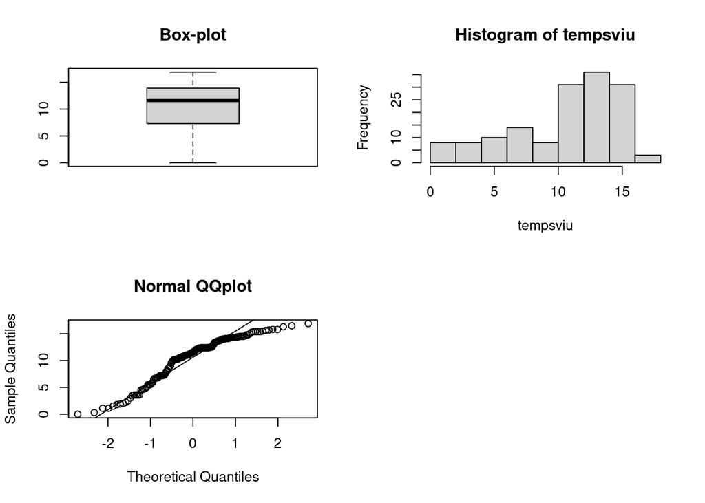

```r
oldpar<-par(mfrow=c(1,1)) # Guarda los parámetros para el dibgujo
par(mfrow=c(2,2)) # Dibuja cuatro gráficos por grafico
with(diabetes, boxplot(tempsviu, main="Box-plot") )

with(diabetes, hist(tempsviu) )

with(diabetes, qqnorm(tempsviu, main="Normal QQplot") );with(diabetes, qqline(tempsviu) )

par(oldpar) # Vuelve a los parámetros de dibujo originales
```

```r
with(diabetes,shapiro.test(tempsviu) ) # Shapiro Wilk test
```

```
##
##  Shapiro-Wilk normality test
##
## data:  tempsviu
## W = 0.92048, p-value = 2.463e-07
```

- Summarise variable by ECG group

```r
diabetes%>%
  group_by(ecg) %>%
  summarise( n=n(),
    mean = mean(tempsviu), median=median(tempsviu),
            sd=sd(tempsviu))
```

| ecg | n | mean | median | sd |
| --- | --- | --- | --- | --- |
| Anormal | 11 | 5.236364 | 5.5 | 2.855967 |
| Frontera | 27 | 8.644444 | 10.2 | 4.038691 |
| Normal | 111 | 11.502703 | 12.4 | 3.678153 |

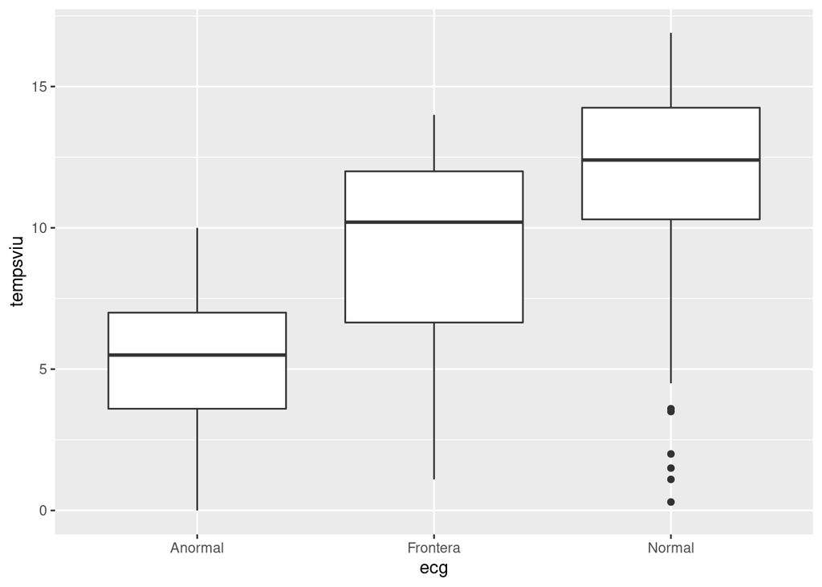

```r
ggplot(diabetes, aes(x=ecg, y=tempsviu)) +
  geom_boxplot()
```

2. Set the hypothesis contrast and perform the test

H0: The means of all the groups are equal H1: Not all the means are equal. At least there are two different means

We will perform a non-parametric test since we can’t assume normality of the data

```r
diabetes_factor%>%
  group_by(ecg) %>%
  summarise(median = median(tempsviu))
```

| ecg | median |
| --- | --- |
| Anormal | 5.5 |
| Frontera | 10.2 |
| Normal | 12.4 |

```r
kruskal.test(tempsviu~ecg,data=diabetes_factor)
```

```
##
##  Kruskal-Wallis rank sum test
##
## data:  tempsviu by ecg
## Kruskal-Wallis chi-squared = 28.977, df = 2, p-value = 5.103e-07
```

- We can reject the null hypothesis (p-value < 0.05)
3. If needed, apply a post-hoc test for multiple comparisons between groups to test which groups are different.

Non-parametric Dunn Test for multiple comparison

```r
# install.packages("dunn.test")
library(dunn.test)
with(diabetes_factor,dunn.test(tempsviu,ecg,method="bonferroni"))
```

```
##   Kruskal-Wallis rank sum test
##
## data: tempsviu and ecg
## Kruskal-Wallis chi-squared = 28.9766, df = 2, p-value = 0
##
##
##                          Comparison of tempsviu by ecg
##                                  (Bonferroni)
## Col Mean-|
## Row Mean |    Anormal   Frontera
## ---------+----------------------
## Frontera |  -1.917822
##          |     0.0827
##   Normal |  -4.532635  -3.480052
##          |    0.0000*    0.0008*
##
## alpha = 0.05
## Reject Ho if p <= alpha/2
```

- Differences between Normal-Anormal groups and between Normal-Frontera groups are significant (adjusted p-value < 0.05).

## Exercise 6

Se estudia un grupo de 33 pacientes afectados de Carcinoma hepatocelular, un grupo de 22 afectados únicamente de cirrosis y un grupo control de 31 donantes de sangre. Se determina la actividad celular NK y el número de células CK en los tres grupos. (Nota: la media de actividad celular es de 39 unidades líticas /10ˆ7 de linfocitos y la mediana es de 28 y la media del número de células es de 178 y la mediana de 163)

Solución: Se dispone de tres grupos de pacientes independientes y dos variables cuantitativas a comparar en los tres grupos. Aunque desconocemos el comportamiento de las variables, por las pistas vemos que las medias y las medianas son bastante diferentes con lo cual la distribución no debe de ser simétrica. Por otra parte el tamaño muestral de los grupos no es muy grande. Optaríamos por efectuar un contraste no paramétrico de igualdad de distribuciones en los tres grupos. Utilizaríamos la prueba de Kruskal-Wallis. Si hay diferencias, para identificar entre qué dos grupos están usaríamos la corrección de Bonferroni del ejercicio anterior o el Dunn-test que ya efectúa los contrastes con la p corregida.